# Handling Missingness, Failures, and Non-Convergence in Simulation Studies

- Show All Code
- Hide All Code
- View Source

Literature Review Analysis

Authors

Samuel Pawel

František Bartoš

Björn S. Siepe

Anna Lohmann

Published

September 26, 2024

# 1 Background

This document contains code to analyze the results of the literature review on missingness in simulation studies.

# 2 Prep

Load all relevant packages and the data:

```r
set.seed(2024)
library(tidyverse)
library(sysfonts)
library(readxl)
library(cowplot)
library(scales)
library(ggpubr)

library(here)

# Load data
data_lr <- readxl::read_xlsx(here("data/sim_res.xlsx"))

# Remove entries for coding interrater agreement
data_lr <- data_lr |>
  filter(id != "agreement" | is.na(id))

# change "other deletion" to "other" for clarity
data_lr <- data_lr |>
  mutate(q3_1_method_dealing_with_missingness = ifelse(q3_1_method_dealing_with_missingness == "other deletion", "other", q3_1_method_dealing_with_missingness))
```

Set some global theme options for plotting:

```r
# Taken from Okabeito
cols <- c("SiM" = "#0072B2", "PM" = "#E69F00", "RSM" = "#009E73", "JASA" = "#F0E442")
# cols <- c("BRM" = "#E69F00", "MBR" = "#56B4E9", "PM" = "#009E73")

# Alternative font
theme_bs <- function(){
  # add google font
  sysfonts::font_add_google("News Cycle", "news")
  # use showtext
  showtext::showtext_auto()

  # theme
  ggplot2::theme_minimal(base_family = "news") +
    ggplot2::theme(
      # remove minor grid
      panel.grid.minor = ggplot2::element_blank(),
      # Title and Axis Texts
      plot.title = ggplot2::element_text(face = "plain",
                                         size = ggplot2::rel(1.2),
                                         hjust = 0.5),
      plot.subtitle = ggplot2::element_text(size = ggplot2::rel(1.1),
                                            hjust = 0.5),
      axis.text.x = ggplot2::element_text(face = "plain", size = 24),
      axis.title.x = ggplot2::element_text(face = "plain", size = 24),
      axis.title.y = ggplot2::element_text(face = "plain", size = 24),
      axis.line = element_line(colour = "#6d6d6e"),

      # Faceting
      strip.text = ggplot2::element_text(face = "plain",
                                         size = ggplot2::rel(1.1),
                                         hjust = 0.5),
      strip.text.x.top = ggplot2::element_text(face = "plain",
                                               size = ggplot2::rel(1.2),
                                               hjust = 0.5),
      # strip.text.y = element_blank(),
      strip.background = ggplot2::element_rect(fill = NA, color = NA),
      # Grid
      panel.grid = ggplot2::element_line(colour = "#F3F4F5"),
      # Legend
      legend.title = ggplot2::element_text(face = "plain"),
      legend.position = "top",
      legend.justification = 1,
      # Panel/Facets
      panel.spacing.x = ggplot2::unit(1.6, "lines"),
      panel.spacing.y = ggplot2::unit(1.6, "lines"),
      # Remove vertical grid lines
      panel.grid.major.x = ggplot2::element_blank(),
      text = ggplot2::element_text(size = 33)

    )
}

theme_set(theme_bs())
```

# 3 Visualizations of Individual Questions

## 3.1 Q0/Q1: Proportion of Sim Studies per Journal/Year/Reviewer

The following plot shows the number of simulation studies per journal (in the darker area) as a proportion of all studies per journal (combined with the non-sim studies in the lighter area).

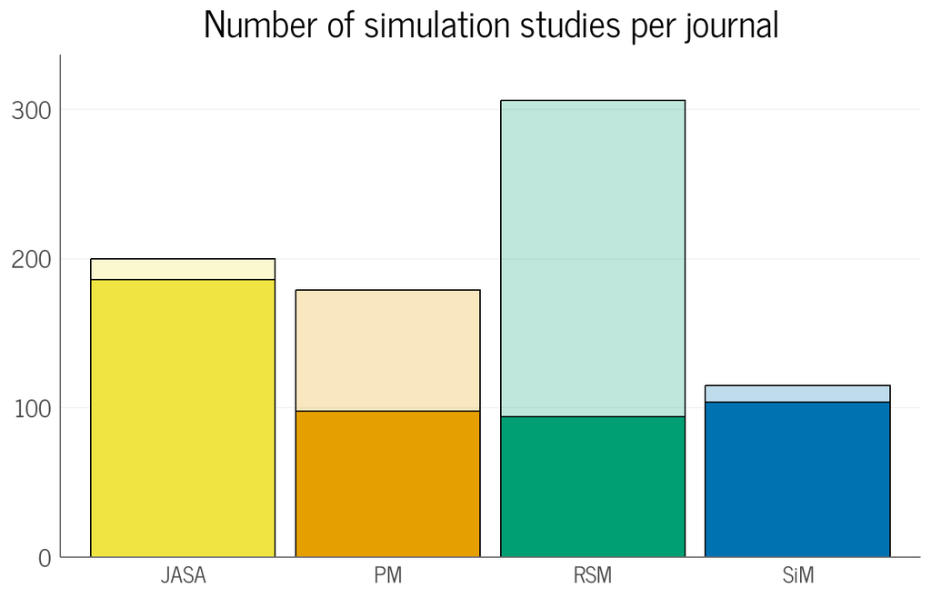

```r
q1_plot_max <- data_lr |>
  count(journal) |>
  pull(n) |>
  max() * 1.1

q1_plot <- data_lr |>
  filter(q1_is_sim_study != "unclear") |>
  ggplot(aes(x = journal, fill = journal, alpha = q1_is_sim_study)) +
    geom_bar(col = 1) +
    labs(x = NULL,
         title ="Number of simulation studies per journal",
         fill = "Journal") +
    # scale_fill_discrete_qualitative(palette = pal) +
    scale_fill_manual(values = cols) +
    scale_alpha_manual(values = c(0.25, 1), guide = "none") +
    scale_y_continuous(limits = c(0, q1_plot_max), expand = c(0,0))+
    theme(panel.grid.major.x = element_blank(),
          legend.position = "none")+
    labs(y = NULL)
q1_plot
```

The following plot shows the proportion of simulation studies per year.

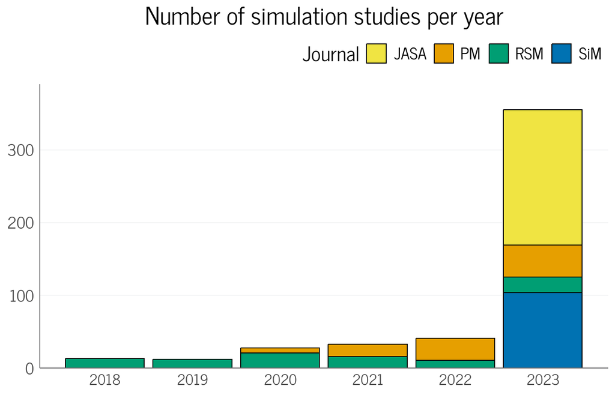

```r
peryear_plot_max <- data_lr |>
  filter(q1_is_sim_study == "yes") |>
  count(year) |>
  pull(n) |>
  max() * 1.1

q1_plot_year <- data_lr |>
  filter(q1_is_sim_study == "yes") |>
  ggplot(aes(x = year, fill = journal)) +
    geom_bar(col = 1) +
    labs(x = NULL,
         title ="Number of simulation studies per year",
         fill = "Journal") +
    scale_fill_manual(values = cols) +
    theme(panel.grid.major.x = element_blank())+
    scale_y_continuous(limits = c(0, peryear_plot_max), expand = c(0,0))+
    scale_x_continuous(breaks = seq(2018, 2023, 1))+
    labs(y = NULL)

q1_plot_year
```

The following plot shows the proportion of simulation studies per reviewer.

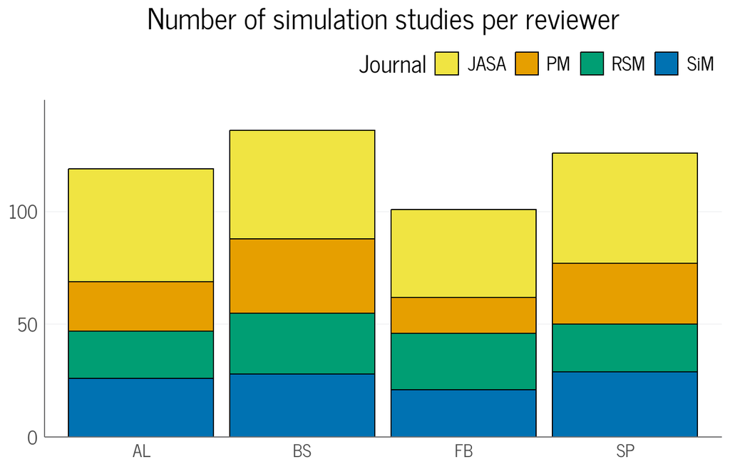

```r
reviewer_plot_max <- data_lr |>
  filter(q1_is_sim_study == "yes") |>
  count(reviewer) |>
  pull(n) |>
  max() * 1.1

q1_plot_rev <- data_lr |>
  filter(q1_is_sim_study == "yes") |>
  ggplot(aes(x = reviewer, fill = journal)) +
    geom_bar(col = 1) +
    labs(x = NULL,
         title ="Number of simulation studies per reviewer",
         fill = "Journal") +
    scale_fill_manual(values = cols) +
    theme(panel.grid.major.x = element_blank())+
    scale_y_continuous(limits = c(0, reviewer_plot_max), expand = c(0,0))+
    labs(y = NULL)
q1_plot_rev
```

## 3.2 Q2: Mention of Missingness

The following plot shows the ratio of simulation studies mentioning some form of missingness.

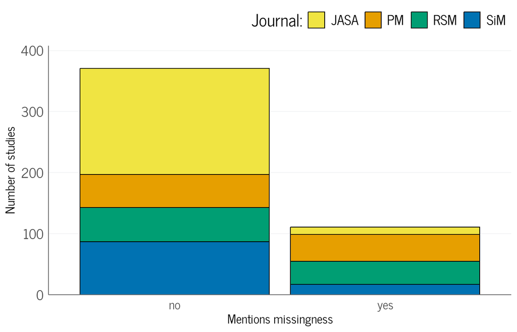

```r
# obtain max for y-axis
q2_plot_max <- data_lr |>
  filter(q1_is_sim_study == "yes") |>
  filter(q2_mentions_missingness == "no") |>
  count() |>
  pull(n) * 1.1

n_mentions <- data_lr |>
  filter(q1_is_sim_study == "yes") |>
  count(q2_mentions_missingness) |>
  filter(q2_mentions_missingness == "yes") |>
  pull(n)

q2_plot <- data_lr |>
  filter(q1_is_sim_study == "yes") |>
  ggplot(aes(x = q2_mentions_missingness, fill = journal, group = journal))+
    geom_bar(col = 1)+
    labs(x = "Mentions missingness", y = "Number of studies", fill = "Journal:")+
    scale_fill_manual(values = cols)+
    theme(panel.grid.major.x = element_blank())+
    scale_y_continuous(limits = c(0, q2_plot_max), expand = c(0,0))
q2_plot
```

Or proportional per journal:

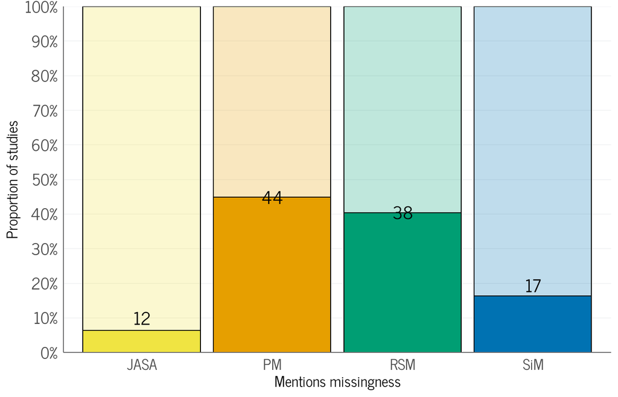

```r
# obtain raw numbers of "yes" mentions per journal
q2_plot_prop_numbers <- data_lr |>
  filter(q1_is_sim_study == "yes") |>
  # divide number of "yes" mentions by total number of studies per journal
  count(journal, q2_mentions_missingness) |>
  group_by(journal) |>
  mutate(pos = n/sum(n)) |>
  filter(q2_mentions_missingness == "yes") |>
  # hard code positioning
  mutate(pos = ifelse(journal == "JASA", pos+0.035, pos)) |>
  mutate(pos = ifelse(journal == "SiM", pos+0.03, pos))


q2_plot_prop <- data_lr |>
  filter(q1_is_sim_study == "yes") |>
  ggplot(aes(alpha = q2_mentions_missingness,
             x = journal,
             fill = journal))+
    geom_bar(position = "fill", col = 1)+
    labs(x = "Mentions missingness",
         y = "Proportion of studies",
         fill = "Journal",
         alpha = "")+
    scale_y_continuous(labels = scales::percent_format(),
                       breaks = seq(0, 1, 0.1),
                       limits = c(0,1), expand = c(0,0))+
    scale_alpha_manual(values = c(0.25, 1), guide = "none")+
    scale_fill_manual(values = cols)+
    theme(panel.grid.major.x = element_blank(),
          legend.position = "none")+
    # add text labels with raw numbers
    geom_text(data = q2_plot_prop_numbers,
              aes(label = n,
                  y = pos,),
                position = position_stack(vjust = 1.09),  # Adjust vjust to move the labels above the lower bar
              size = 10)

q2_plot_prop
```

### 3.2.1 Q2a: Place of Missingness Mention

If missingness was mentioned, where was it reported?

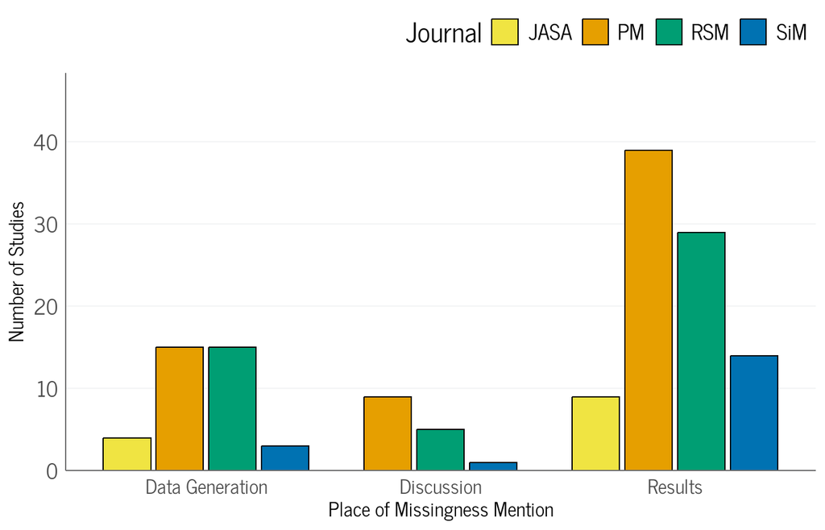

```r
q2a_plot_max <- data_lr |>
  filter(q1_is_sim_study == "yes") |>
  filter(q2_mentions_missingness == "yes") |>
  group_by(journal) |>
  count() |>
  pull(n) |>
  max() * 1.1

q2a_plot <- data_lr |>
  filter(q1_is_sim_study == "yes") |>
  filter(q2_mentions_missingness == "yes") |>
  pivot_longer(cols = all_of(contains("mentions_missingness_")),
               names_to = "place_of_missingness",
               values_to = "value") |>
  mutate(place_of_missingness = str_remove(place_of_missingness, "mentions_missingness_")) |>
  filter(value == TRUE) |>
  group_by(journal, place_of_missingness) |>
  summarise(place_count = n()) |>
  # nicer naming
  mutate(place_of_missingness = case_match(place_of_missingness,
    "q2b_data_generation" ~ "Data Generation",
    "q2c_results" ~ "Results",
    "q2a_discussion" ~ "Discussion",
  )) |>
  ggplot(aes(x = place_of_missingness, y = place_count, fill = journal, group = journal))+
  geom_bar(stat = "identity",
           position = position_dodge2(preserve = "single"),
           col = 1) +
  labs(x = "Place of Missingness Mention", y = "Number of Studies", fill = "Journal")+
  scale_fill_manual(values = cols)+
  scale_y_continuous(limits = c(0, q2a_plot_max), expand = c(0,0))
q2a_plot
```

### 3.2.2 Q2.1: Missingness Reporting

How is missingness reported if it is mentioned? This excludes the additional ‘other’ comment for now.

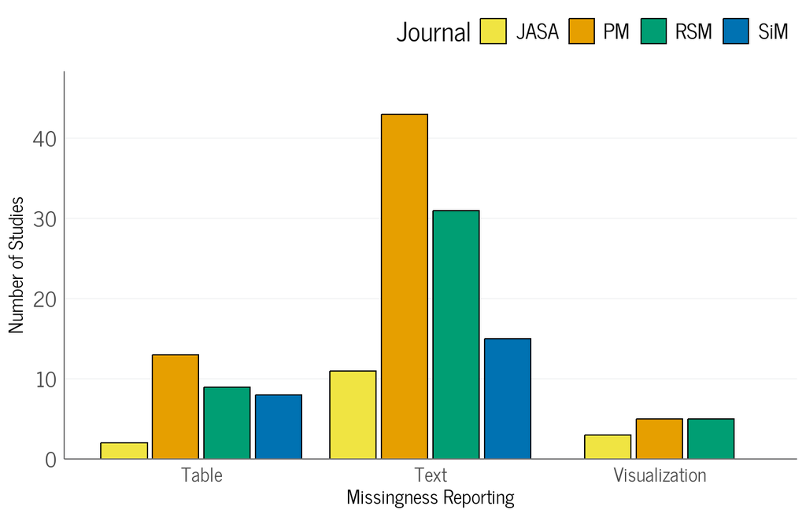

```r
q2_1_plot_max <- data_lr |>
  filter(q1_is_sim_study == "yes") |>
  filter(q2_mentions_missingness == "yes") |>
  group_by(journal) |>
  count() |>
  pull(n) |>
  max() * 1.1


q2_1_plot <- data_lr |>
  filter(q1_is_sim_study == "yes") |>
  filter(q2_mentions_missingness == "yes") |>
  select(journal, q2_1a_missingness_sumarized_text,
         q2_1b_missingness_sumarized_table, q2_1c_missingness_sumarized_visualization) |>
  pivot_longer(cols = -journal,
               names_to = "missingness_reporting",
               values_to = "value") |>
  filter(value == TRUE) |>
  group_by(journal, missingness_reporting) |>
  summarise(reporting_count = n()) |>
  mutate(missingness_reporting = case_match(missingness_reporting,
    "q2_1a_missingness_sumarized_text" ~ "Text",
    "q2_1b_missingness_sumarized_table" ~ "Table",
    "q2_1c_missingness_sumarized_visualization" ~ "Visualization",
  )) |>
  ggplot(aes(x = missingness_reporting, y = reporting_count, fill = journal, group = journal))+
  geom_bar(stat = "identity",
           position = position_dodge2(preserve = "single"),
           col = 1) +
  labs(x = "Missingness Reporting", y = "Number of Studies", fill = "Journal")+
  scale_fill_manual(values = cols)+
  scale_y_continuous(limits = c(0, q2_1_plot_max), expand = c(0,0))+
  theme_bs()
q2_1_plot
```

### 3.2.3 Q2.2: Missigness Summary

How are the missing cases summarized? ‘Prop.’ stands for proportion, so ‘prop. (method/condition)’ would be the missingness proportion per method and condition.

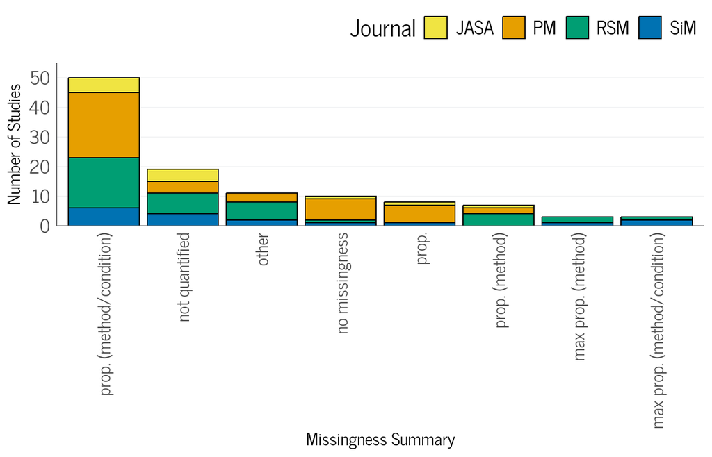

```r
q2_2_plot_max <- data_lr |>
  filter(q1_is_sim_study == "yes") |>
  filter(q2_mentions_missingness == "yes") |>
  count(q2_2_missingness_summarized) |>
  pull(n) |>
  max() * 1.1

n_quantified <- data_lr |>
  filter(q1_is_sim_study == "yes") |>
  filter(q2_mentions_missingness == "yes") |>
  count(q2_2_missingness_summarized) |>
  filter(!q2_2_missingness_summarized == "not quantified") |>
  pull(n) |>
  sum()

q2_2_plot <- data_lr |>
  filter(q1_is_sim_study == "yes") |>
  filter(q2_mentions_missingness == "yes") |>
    mutate(q2_2_missingness_summarized = case_match(q2_2_missingness_summarized,
       "missing proportion (total)" ~ "prop.",
       "missing proportion (per method/condition)" ~ "prop. (method/condition)",
       "max missing proportion (per method/condition)" ~ "max prop. (method/condition)",
       "missing proportion (per method)" ~ "prop. (method)",
       "max missing proportion (per method)" ~ "max prop. (method)",
       "zero missingness" ~ "no missingness",
       .default = q2_2_missingness_summarized

  )) |>
  mutate(q2_2_missingness_summarized = fct_infreq(q2_2_missingness_summarized)) |>
  ggplot(aes(x = q2_2_missingness_summarized, fill = journal, group = journal))+
  geom_bar(col = 1)+
  labs(x = "Missingness Summary", y = "Number of Studies", fill = "Journal")+
  scale_fill_manual(values = cols)+
  scale_y_continuous(limits = c(0, q2_2_plot_max), expand = c(0,0))+
  theme(axis.text.x = element_text(angle = 90, vjust = 0.5, hjust = 1))

q2_2_plot
```

This means that out of the 111 studies mentioning missingness, 92 studies quantified missingness.

Or, as a table with percentages as reported in the manuscript:

```r
data_lr |>
  filter(q1_is_sim_study == "yes") |>
  filter(q2_mentions_missingness == "yes") |>
    mutate(q2_2_missingness_summarized = case_match(q2_2_missingness_summarized,
       "missing proportion (total)" ~ "prop.",
       "missing proportion (per method/condition)" ~ "prop. (method/condition)",
       "max missing proportion (per method/condition)" ~ "max prop. (method/condition)",
       "missing proportion (per method)" ~ "prop. (method)",
       "max missing proportion (per method)" ~ "max prop. (method)",
       "zero missingness" ~ "no missingness",
       .default = q2_2_missingness_summarized

  )) |>
  mutate(q2_2_missingness_summarized = fct_infreq(q2_2_missingness_summarized)) |>
  count(q2_2_missingness_summarized) |>
  mutate(percentage = paste0(round(n / sum(n) * 100, 1), "%")) |>
  rename("Missingness Summary" = q2_2_missingness_summarized) |>
  knitr::kable()
```

| Missingness Summary | n | percentage |
| --- | --- | --- |
| prop. (method/condition) | 50 | 45% |
| not quantified | 19 | 17.1% |
| other | 11 | 9.9% |
| no missingness | 10 | 9% |
| prop. | 8 | 7.2% |
| prop. (method) | 7 | 6.3% |
| max prop. (method) | 3 | 2.7% |
| max prop. (method/condition) | 3 | 2.7% |

## 3.3 Q3: Handling of Missingness

We first decided that studies that explicitly report that no missingness occurred get their own category for question 3:

```r
data_lr <- data_lr |>
    mutate(q3_report_dealing_with_missingness = if_else(q2_2_missingness_summarized == "zero missingness",
                                                      "yes\n(zero)",
                                                      q3_report_dealing_with_missingness))
```

The following plot shows, conditional on mentioning missingness, how authors reported how they handled missingness.

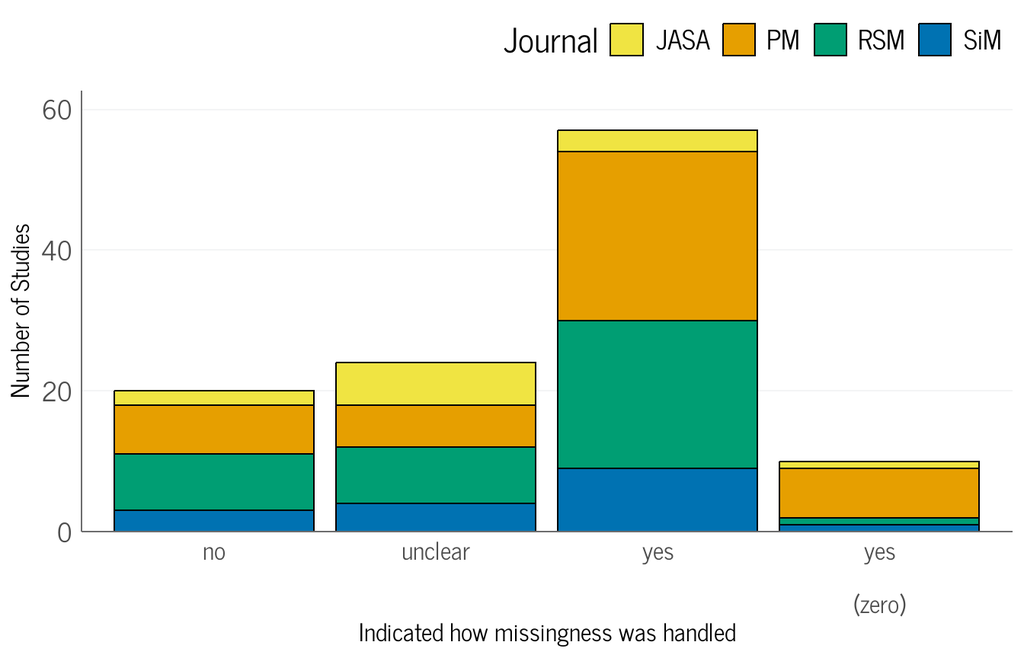

```r
q3_plot_max <- data_lr |>
  filter(q1_is_sim_study == "yes") |>
  filter(q2_mentions_missingness == "yes") |>
  group_by(q3_report_dealing_with_missingness) |>
  count() |>
  pull(n) |>
  max() * 1.1

q3_plot <- data_lr |>
  filter(q1_is_sim_study == "yes") |>
  filter(q2_mentions_missingness == "yes") |>
  ggplot(aes(x = q3_report_dealing_with_missingness, fill = journal, group = journal))+
    geom_bar(col = 1)+
    labs(x = "Indicated how missingness was handled", y = "Number of Studies", fill = "Journal")+
    scale_fill_manual(values = cols)+
    scale_y_continuous(limits = c(0, q3_plot_max), expand = c(0,0))+
    theme(panel.grid.major.x = element_blank())
q3_plot
```

Or, alternatively, with an own category for “missingness not mentioned”.

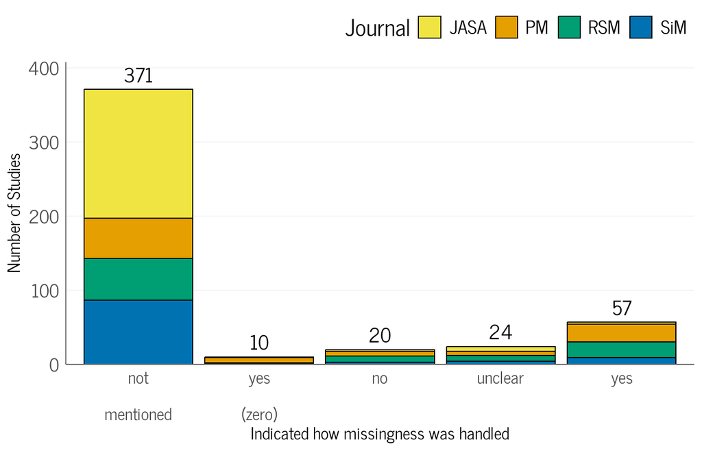

```r
q3_nonmention_plot_max <- data_lr |>
  filter(q1_is_sim_study == "yes") |>
  filter(q2_mentions_missingness == "no") |>
  count() |>
  pull(n) |>
  max() * 1.1


# calculate raw numbers
q3_nonmention_counts <- data_lr |>
  filter(q1_is_sim_study == "yes") |>
  mutate(q3_report_dealing_with_missingness = if_else(q2_mentions_missingness == "no",
                                                      "not\nmentioned",
                                                      q3_report_dealing_with_missingness)) |>

  count(q3_report_dealing_with_missingness)


q3_plot_nonmention <- data_lr |>
  filter(q1_is_sim_study == "yes") |>
  mutate(q3_report_dealing_with_missingness = if_else(q2_mentions_missingness == "no",
                                                      "not\nmentioned",
                                                      q3_report_dealing_with_missingness)) |>
  mutate(q3_report_dealing_with_missingness = factor(q3_report_dealing_with_missingness,
                                                     levels = c("not\nmentioned",
                                                                "yes\n(zero)",
                                                                "no",
                                                                "unclear",
                                                                "yes"))) |>
  ggplot(aes(x = q3_report_dealing_with_missingness, fill = journal, group = journal))+
    geom_bar(col = 1)+
    labs(x = "Indicated how missingness was handled", y = "Number of Studies", fill = "Journal")+
    scale_fill_manual(values = cols)+
    scale_y_continuous(limits = c(0, q3_nonmention_plot_max), expand = c(0,0))+
    theme(panel.grid.major.x = element_blank())+
    # add raw numbers
    geom_text(data = q3_nonmention_counts,
              aes(x = q3_report_dealing_with_missingness, y = n, label = n),
              vjust = -0.5, size = 10, inherit.aes = FALSE)

q3_plot_nonmention
```

Overall, 67 studies mentioned missingness and reported how they handled it, including 10 studies that explicitly reported that no missingness occurred.

### 3.3.1 Q3.1: Method of Handling Missingness

If authors report how they dealt with missingness, what method did they use? Here, we are looking at 81 studies where missingness occurred and some form of missingness handling was documented, even if it was (partly) unclear.

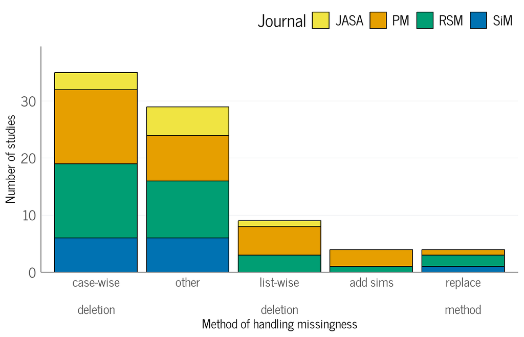

```r
q31_plot_max <- data_lr |>
  filter(q1_is_sim_study == "yes") |>
  filter(q2_mentions_missingness == "yes") |>
  # filter(q3_report_dealing_with_missingness == "yes") |>
  group_by(q3_1_method_dealing_with_missingness) |>
  count() |>
  pull(n) |>
  max() * 1.1

q3_1_plot <- data_lr |>
  filter(q1_is_sim_study == "yes") |>
  filter(q2_mentions_missingness == "yes") |>
  filter(q3_report_dealing_with_missingness == "yes" | q3_report_dealing_with_missingness == "unclear") |>
  # change NA to "other" -> was missingness as outcome
  mutate(q3_1_method_dealing_with_missingness = if_else(is.na(q3_1_method_dealing_with_missingness),
                                                        "other",
                                                        q3_1_method_dealing_with_missingness)) |>
  mutate(q3_1_method_dealing_with_missingness = case_match(q3_1_method_dealing_with_missingness,
                                                           "additional simulations" ~ "add sims",
                                                           "method replacement" ~ "replace method",
                                                           .default = q3_1_method_dealing_with_missingness)) |>

  # order q3_1 by frequency
  mutate(q3_1_method_dealing_with_missingness = fct_infreq(q3_1_method_dealing_with_missingness)) |>
  ggplot(aes(x = q3_1_method_dealing_with_missingness, fill = journal, group = journal))+
    geom_bar(col = 1)+
    labs(x = "Method of handling missingness", y = "Number of studies", fill = "Journal")+
    scale_x_discrete(labels = scales::label_wrap(10))+
    scale_fill_manual(values = cols)+
    scale_y_continuous(limits = c(0, q31_plot_max), expand = c(0,0))+
    theme(panel.grid.major.x = element_blank())
          # axis.text.x = element_text(angle = 90, vjust = 0.5, hjust = 1))
q3_1_plot
```

Alternatively, reported in a table with percentages as reported in the manuscript:

```r
data_lr |>
  filter(q1_is_sim_study == "yes") |>
  filter(q2_mentions_missingness == "yes") |>
  filter(q3_report_dealing_with_missingness == "yes" | q3_report_dealing_with_missingness == "unclear") |>
  # change NA to "other" -> was missingness as outcome
  mutate(q3_1_method_dealing_with_missingness = if_else(is.na(q3_1_method_dealing_with_missingness),
                                                        "other",
                                                        q3_1_method_dealing_with_missingness)) |>
  mutate(q3_1_method_dealing_with_missingness = case_match(q3_1_method_dealing_with_missingness,
                                                           "additional simulations" ~ "add sims",
                                                           "method replacement" ~ "replace method",
                                                           .default = q3_1_method_dealing_with_missingness)) |>

  # order q3_1 by frequency
  mutate(q3_1_method_dealing_with_missingness = fct_infreq(q3_1_method_dealing_with_missingness)) |>
  count(q3_1_method_dealing_with_missingness) |>
  mutate(percentage = paste0( round(n/sum(n)*100, 1), "%")) |>
  rename("Method" = q3_1_method_dealing_with_missingness) |>
  knitr::kable()
```

| Method | n | percentage |
| --- | --- | --- |
| case-wise deletion | 35 | 43.2% |
| other | 29 | 35.8% |
| list-wise deletion | 9 | 11.1% |
| add sims | 4 | 4.9% |
| replace method | 4 | 4.9% |

### 3.3.2 Q3.2: Missingness Handling Justification

If authors report how they dealt with missingness, what justification did they provide for their choice? We filter out one study here where missingness was considered as the outcome, so there is no justification needed. Overall, 21 studies some form of justification of their choice, including 5 studies that provided an unclear justification. In the following, we agreed to count NA in `q3_2_method_justification` as no.

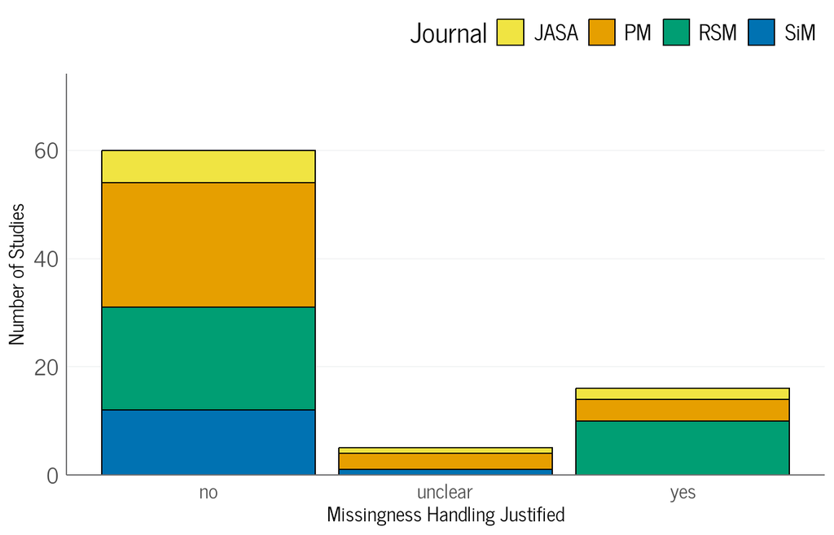

```r
q32_plot_max <- data_lr |>
  filter(q1_is_sim_study == "yes") |>
  filter(q2_mentions_missingness == "yes") |>
  filter(q3_report_dealing_with_missingness == "yes" | q3_report_dealing_with_missingness == "unclear") |>
  group_by(q3_2_method_justification) |>
  count() |>
  pull(n) |>
  max() * 1.4

q3_2_plot <- data_lr |>
  filter(q1_is_sim_study == "yes") |>
  filter(q2_mentions_missingness == "yes") |>
  filter(q3_report_dealing_with_missingness == "yes" | q3_report_dealing_with_missingness == "unclear") |>
    mutate(q3_2_method_justification = if_else(is.na(q3_2_method_justification), "no",
                                             q3_2_method_justification)) |>
  ggplot(aes(x = q3_2_method_justification, fill = journal, group = journal))+
    geom_bar(col = 1)+
    labs(x = "Missingness Handling Justified", y = "Number of Studies", fill = "Journal")+
    scale_fill_manual(values = cols)+
    scale_y_continuous(limits = c(0, q32_plot_max), expand = c(0,0))+
    theme(panel.grid.major.x = element_blank())
q3_2_plot
```

Again, a table with percentages:

```r
data_lr |>
  filter(q1_is_sim_study == "yes") |>
  filter(q2_mentions_missingness == "yes") |>
  filter(q3_report_dealing_with_missingness == "yes" | q3_report_dealing_with_missingness == "unclear") |>
  mutate(q3_2_method_justification = if_else(is.na(q3_2_method_justification), "no",
                                             q3_2_method_justification)) |>
  count(q3_2_method_justification) |>
  mutate(percentage = paste0( round(n/sum(n)*100, 1), "%")) |>
  rename("Justification" = q3_2_method_justification) |>
  knitr::kable()
```

| Justification | n | percentage |
| --- | --- | --- |
| no | 60 | 74.1% |
| unclear | 5 | 6.2% |
| yes | 16 | 19.8% |

#### 3.3.2.1 Q 3.3. Type of Justification

If authors provide a justification for their choice of handling missingness, what type of justification do they provide? This includes all studies with a clear or unclear justification as long as some form of justification is provided.

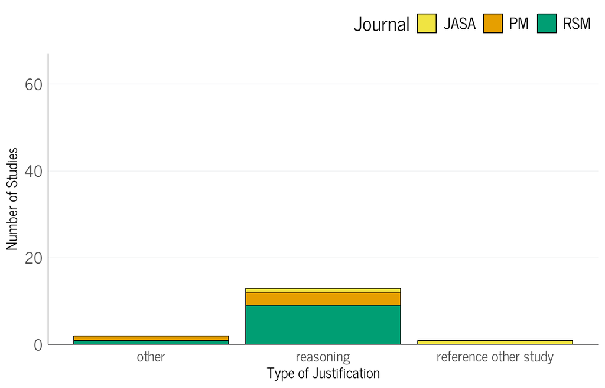

```r
q33_plot_max <- data_lr |>
  filter(q1_is_sim_study == "yes") |>
  filter(q2_mentions_missingness == "yes") |>
  filter(q3_report_dealing_with_missingness == "yes" | q3_report_dealing_with_missingness == "unclear") |>
  group_by(q3_3_type_justification) |>
  count() |>
  pull(n) |>
  max() * 1.1

q3_3_plot <- data_lr |>
  filter(q1_is_sim_study == "yes") |>
  filter(q2_mentions_missingness == "yes") |>
  filter(q3_report_dealing_with_missingness == "yes" | q3_report_dealing_with_missingness == "unclear") |>
  filter(q3_2_method_justification == "yes") |>
  ggplot(aes(x = q3_3_type_justification, fill = journal, group = journal))+
    geom_bar(col = 1)+
    labs(x = "Type of Justification", y = "Number of Studies", fill = "Journal")+
    scale_fill_manual(values = cols)+
    scale_y_continuous(limits = c(0, q33_plot_max), expand = c(0,0))+
    theme(panel.grid.major.x = element_blank())

q3_3_plot
```

As a table:

```r
data_lr |>
  filter(q1_is_sim_study == "yes") |>
  filter(q2_mentions_missingness == "yes") |>
  filter(q3_report_dealing_with_missingness == "yes" | q3_report_dealing_with_missingness == "unclear") |>
  filter(!is.na(q3_3_type_justification)) |>
  count(q3_3_type_justification) |>
  mutate(percentage = paste0( round(n/sum(n)*100, 1), "%")) |>
  rename("Justification Type" = q3_3_type_justification) |>
  knitr::kable()
```

| Justification Type | n | percentage |
| --- | --- | --- |
| other | 4 | 20% |
| reasoning | 14 | 70% |
| reference other study | 2 | 10% |

## 3.4 Q4: Code Availability

If the study was a simulation study, was code available?

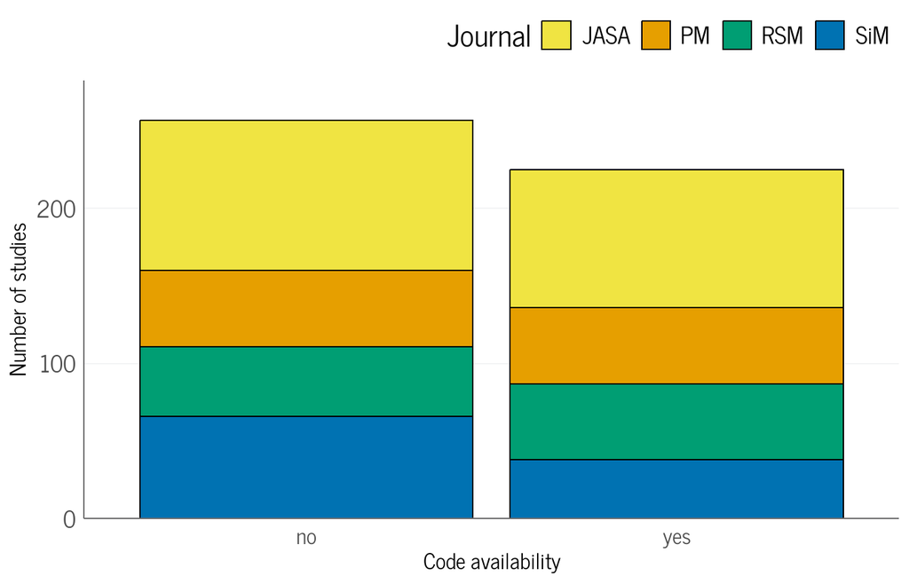

```r
q4_plot_max <- data_lr |>
  filter(q1_is_sim_study == "yes") |>
  group_by(q4_code_available) |>
  count() |>
  pull(n) |>
  max() * 1.1

q4_plot <- data_lr |>
  filter(q1_is_sim_study == "yes") |>
  ggplot(aes(x = q4_code_available, fill = journal, group = journal))+
    geom_bar(col = 1)+
    labs(x = "Code availability", y = "Number of studies", fill = "Journal")+
    scale_fill_manual(values = cols)+
    scale_y_continuous(limits = c(0, q4_plot_max), expand = c(0,0))+
    theme(panel.grid.major.x = element_blank())
q4_plot
```

This means that, overall, 46.7% of the simulation studies provided code.

The same, but per journal:

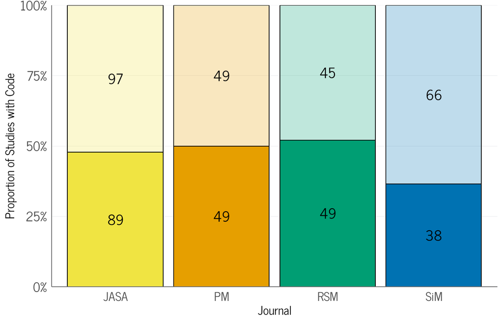

```r
# compute raw numbers and proportions
q4_counts <- data_lr |>
  filter(q1_is_sim_study == "yes") |>
  filter(!is.na(q4_code_available)) |>
  group_by(journal, q4_code_available) |>
  count() |>
  group_by(journal) |>
  mutate(prop = n/sum(n))



q4_plot_prop <- data_lr |>
  filter(q1_is_sim_study == "yes") |>
  filter(!is.na(q4_code_available)) |>
  ggplot(aes(alpha = q4_code_available, x = journal, fill = journal))+
    geom_bar(col = 1, position = "fill")+
  theme(legend.position = "none") +
   scale_alpha_manual(values = c(0.25, 1), guide = "none") +
  scale_y_continuous(labels = scales::percent_format(),
                     limits = c(0,1), expand = c(0,0)) +
    labs(x = "Journal", y = "Proportion of Studies with Code", fill = "Journal")+
    scale_fill_manual(values = cols) +
   geom_text(data = q4_counts,
             aes(x = journal,
                 y = prop,
                 group = q4_code_available,
                 label = n),
             position = position_stack(vjust = 0.5),
             size = 10,
             inherit.aes = FALSE)
q4_plot_prop
```

Or as a table with percentages:

```r
data_lr |>
  filter(q1_is_sim_study == "yes") |>
  count(journal, q4_code_available) |>
  group_by(journal) |>
  mutate(prop = n/sum(n)) |>
  mutate(percentage = paste0(round(prop*100, 1), "%")) |>
  select(!prop) |>
  rename("Code Availability" = q4_code_available) |>
  knitr::kable()
```

| journal | Code Availability | n | percentage |
| --- | --- | --- | --- |
| JASA | no | 97 | 52.2% |
| JASA | yes | 89 | 47.8% |
| PM | no | 49 | 50% |
| PM | yes | 49 | 50% |
| RSM | no | 45 | 47.9% |
| RSM | yes | 49 | 52.1% |
| SiM | no | 66 | 63.5% |
| SiM | yes | 38 | 36.5% |

# 4 Combined Plots for Manuscript

## 4.1 Tweak existing plots

First, slightly tweak the plots for the combined figure:

During the revision of the manuscript, thanks to the helpful comment of a reviewer, we renamed “case-wise” and “list-wise” deletion to “method-wise” and “repetition-wise” deletion, respectively.

```r
# studies per journal (excluding "unclear")
q1_totals <- data_lr |>
  filter(q1_is_sim_study != "unclear") |>
  count(journal, name = "total")

q1_sim_counts <- data_lr |>
  filter(q1_is_sim_study == "yes") |>
  count(journal, name = "sim")

q1_labels <- left_join(q1_sim_counts, q1_totals, by = "journal") |>
  mutate(label = paste0(sim, "/", total),
         prop = sim / total)


q1_plot_pub <- data_lr |>
  filter(q1_is_sim_study != "unclear") |>
  count(journal, q1_is_sim_study) |>
  group_by(journal) |>
  mutate(prop = n/sum(n)) |>
  ungroup() |>
  filter(q1_is_sim_study == "yes") |>
  ggplot(aes(x = journal, y = prop, fill = journal)) +
    geom_col(col = 1) +
    labs(x = NULL,
         title ="Simulation studies per journal",
         fill = "Journal") +
    # add raw numbers
  geom_text(data = q1_labels,
          aes(x = journal, y = prop/2, label = label),
          size = 5.8, inherit.aes = FALSE, position = position_stack(vjust = 0.5))+
                             theme(legend.position = "none",
                                  text = element_text(size = 18),
                                  axis.text.x = element_text(size = 18),
                                  axis.text.y = element_text(size = 18),
                                  axis.title.y = element_text(size = 16))+
    # scale_fill_discrete_qualitative(palette = pal) +
    scale_fill_manual(values = cols) +
    # scale_alpha_manual(values = c(0.25, 1), guide = "none") +
      scale_y_continuous(labels = scales::percent_format(),
                     limits = c(0,1), expand = c(0,0)) +
    theme(panel.grid.major.x = element_blank(),
          legend.position = "none",
          text = element_text(size = 17.5))+
    labs(y = NULL)



q3_nonmention_plot_max <- data_lr |>
  filter(q1_is_sim_study == "yes") |>
  filter(q2_mentions_missingness == "no") |>
  count() |>
  pull(n) |>
  max() * 1.1
q3_nonmention_plot_max_pub <- q3_nonmention_plot_max * 1.1
q3_plot_nonmention_pub <- data_lr |>
  filter(q1_is_sim_study == "yes") |>
  mutate(q3_report_dealing_with_missingness = if_else(q2_2_missingness_summarized == "zero missingness",
                                                      "yes\n(zero)",
                                                      q3_report_dealing_with_missingness)) |>
  mutate(q3_report_dealing_with_missingness = if_else(q2_mentions_missingness == "no",
                                                      "not\nmentioned",
                                                      q3_report_dealing_with_missingness)) |>

  mutate(q3_report_dealing_with_missingness = factor(q3_report_dealing_with_missingness,
                                                     levels = c("not\nmentioned",
                                                                "yes\n(zero)",
                                                                "no",
                                                                "unclear",
                                                                "yes"))) |>
  ggplot(aes(x = q3_report_dealing_with_missingness, fill = journal, group = journal))+
    geom_bar(col = 1)+
    labs(x = "Indicated how missingness was handled", y = "Number of Studies", fill = "Journal:")+
    scale_fill_manual(values = cols)+
    scale_y_continuous(limits = c(0, q3_nonmention_plot_max_pub), expand = c(0, 0.2))+
    # add raw numbers
    geom_text(data = q3_nonmention_counts,
              aes(x = q3_report_dealing_with_missingness, y = n, label = n),
              vjust = -0.5, size = 5.8, inherit.aes = FALSE) +
                             theme(legend.position = "none",
                                  text = element_text(size = 18),
                                  axis.text.x = element_text(size = 18),
                                  axis.text.y = element_text(size = 18),
                                  axis.title.y = element_text(size = 16))+
                             labs(x = NULL,
                                  y = NULL,
                                  title = "Missingness handling reported?")+
  ggpubr::geom_bracket(xmin = 1.75, xmax = 5.25,
               inherit.aes = FALSE, label = "If mentioned",
               y.position = 135, label.size = 5.8)


# obtain counts for plotting
q3_1_plot_counts <- data_lr |>
  filter(q1_is_sim_study == "yes") |>
  filter(q2_mentions_missingness == "yes") |>
  filter(q3_report_dealing_with_missingness == "yes" | q3_report_dealing_with_missingness == "unclear") |>
    mutate(
    q3_1_method_dealing_with_missingness = if_else(
      is.na(q3_1_method_dealing_with_missingness),
      "other",
      q3_1_method_dealing_with_missingness
    )
  ) |>
  mutate(
    q3_1_method_dealing_with_missingness = case_match(
      q3_1_method_dealing_with_missingness,
      "additional simulations" ~ "add sims",
      "method replacement" ~ "replace",
      "case-wise deletion" ~ "method- wise",
      "list-wise deletion" ~ "repetition- wise",
      .default = q3_1_method_dealing_with_missingness
    )
  ) |>
  count(q3_1_method_dealing_with_missingness) |>
  mutate(prop = n/sum(n))

q31_plot_max_pub <- q31_plot_max * 1.05
q3_1_plot_pub <- data_lr |>
  filter(q1_is_sim_study == "yes") |>
  filter(q2_mentions_missingness == "yes") |>
  filter(q3_report_dealing_with_missingness == "yes" | q3_report_dealing_with_missingness == "unclear") |>
  # change NA to "outcome"
  mutate(
    q3_1_method_dealing_with_missingness = if_else(
      is.na(q3_1_method_dealing_with_missingness),
      "other",
      q3_1_method_dealing_with_missingness
    )
  ) |>
  mutate(
    q3_1_method_dealing_with_missingness = case_match(
      q3_1_method_dealing_with_missingness,
      "additional simulations" ~ "add sims",
      "method replacement" ~ "replace",
      "case-wise deletion" ~ "method- wise",
      "list-wise deletion" ~ "repetition- wise",
      .default = q3_1_method_dealing_with_missingness
    )
  ) |>
  # order q3_1 by frequency
  mutate(q3_1_method_dealing_with_missingness = fct_infreq(q3_1_method_dealing_with_missingness)) |>
  ggplot(aes(x = q3_1_method_dealing_with_missingness, fill = journal, group = journal)) +
  geom_bar(col = 1) +
  geom_text(data = q3_1_plot_counts,
            aes(x = q3_1_method_dealing_with_missingness,
                y = n,
                label = n),
            vjust = -0.5,
            size = 5.8,
            inherit.aes = FALSE) +
  labs(x = "Method of handling missingness", y = "Number of studies", fill = "Journal:") +
  scale_x_discrete(labels = scales::label_wrap(4)) +
  scale_fill_manual(values = cols) +
  scale_y_continuous(limits = c(0, q31_plot_max_pub), expand = c(0, 0.2)) +
  theme(legend.position = "none",
                                  text = element_text(size = 18),
                                  axis.text.x = element_text(size = 18),
                                  axis.text.y = element_text(size = 18))+
                             labs(x = NULL,
                                  y = NULL,
                                  title = "Method of handling missingness")



# sim studies with known code availability per journal
q4_totals <- data_lr |>
  filter(q1_is_sim_study == "yes") |>
  filter(!is.na(q4_code_available)) |>
  count(journal, name = "total")

q4_code_yes <- data_lr |>
  filter(q1_is_sim_study == "yes", q4_code_available == "yes") |>
  count(journal, name = "yes_count")

q4_labels <- left_join(q4_code_yes, q4_totals, by = "journal") |>
  mutate(label = paste0(yes_count, "/", total),
         prop = yes_count / total)


q4_plot_prop_pub <- data_lr |>
  filter(q1_is_sim_study == "yes") |>
  filter(!is.na(q4_code_available)) |>
  count(journal, q4_code_available) |>
  group_by(journal) |>
  mutate(prop = n/sum(n)) |>
  ungroup() |>
  filter(q4_code_available == "yes") |>
  ggplot(aes(x = journal, y = prop, fill = journal))+
    geom_col(col = 1)+
  theme(legend.position = "none") +
   # scale_alpha_manual(values = c(0.25, 1), guide = "none") +
  scale_y_continuous(labels = scales::percent_format(),
                     limits = c(0,1), expand = c(0,0)) +
    labs(x = "Journal", y = "Proportion of Studies with Code", fill = "Journal:")+
    scale_fill_manual(values = cols) +
   geom_text(data = q4_labels,
          aes(x = journal, y = prop/2, label = label),
          position = position_stack(vjust = 0.5),
          size = 5.8,
          inherit.aes = FALSE)+
    theme(legend.position = "none",
          text = element_text(size = 18),
                                  axis.text.x = element_text(size = 18),
                                  axis.text.y = element_text(size = 18),
          axis.title.y = element_text(size = 16))+
    labs(x = NULL,
         y = NULL,
         title = "Code for simulation study available?")+
  theme(panel.background = element_rect(colour = "#F3F4F5"))
```

For the first revision, we tried to change the first and last part of the plot to show absolut numbers instead of proportions, and add the total number of studies as a label. However, in the end, we kept the original proportion plot, but removed the shaded “no” area.

```r
# slightly hacky to get colors in correct order
cols_rev <- unname(cols)
cols_rev <- cols_rev[c(4,2,3,1)]

# get counts
q1_rev_plot_counts <- data_lr |>
  count(journal, q1_is_sim_study) |>
  # filter(q1_is_sim_study == "yes") |>
  # add overall count to each journal
  group_by(journal) |>
  mutate(n_journal = sum(n)) |>
  ungroup() |>
  mutate(journal = as.factor(paste(journal, "\n(n = ", n_journal, ")", sep = ""))) |>
  filter(q1_is_sim_study == "yes")


q1_plot_rev1 <- data_lr |>
  add_count(journal) |>
  filter(q1_is_sim_study != "unclear") |>
  filter(q1_is_sim_study != "no") |>
  # add the count to the x axis label (journal column)
  mutate(journal = as.factor(paste(journal, "\n(n = ", n, ")", sep = ""))) |>
  ggplot(aes(x = journal,
             fill = journal)) +
  geom_bar(col = 1) +
    labs(x = NULL,
         title ="Number of simulation studies per journal",
         fill = "Journal") +
   # slightly hacky to get colors in correct order
    scale_fill_manual(values = cols_rev) +
    scale_alpha_manual(values = c(0.25, 1), guide = "none") +
    scale_y_continuous(limits = c(0,210), expand = c(0,0)) +
    theme(panel.grid.major.x = element_blank(),
          legend.position = "none",
          text = element_text(size = 17.5))+
    labs(y = NULL)+
    # add counts to the bars
    geom_text(data = q1_rev_plot_counts,
              aes(x = journal, y = n, label = n),
              size = 5.8,
              inherit.aes = FALSE, vjust = -0.5)+
    theme(legend.position = "none",
          text = element_text(size = 18),
                                  axis.text.x = element_text(size = 18),
                                  axis.text.y = element_text(size = 18),
          axis.title.y = element_text(size = 16))




q4_counts_rev <- data_lr |>
  filter(q1_is_sim_study == "yes") |>
  count(journal, q4_code_available) |>
  group_by(journal) |>
  mutate(n_journal = sum(n)) |>
  ungroup() |>
  # select(!n) |>
  filter(q4_code_available == "yes") |>
  rename(n_code = n) |>
  mutate(journal = as.factor(paste(journal, "\n(n = ", n_journal, ")", sep = "")))

q4_plot_rev1 <- data_lr |>
  filter(q1_is_sim_study == "yes") |>
  add_count(journal) |>
  filter(!is.na(q4_code_available)) |>
  filter(q4_code_available == "yes") |>
  mutate(journal = as.factor(paste(journal, "\n(n = ", n, ")", sep = "")) ) |>
  ggplot(aes(x = journal, fill = journal))+
  geom_bar(col = 1)+
  theme(legend.position = "none") +
  scale_y_continuous(limits = c(0,100), expand = c(0,0)) +
  labs(x = "Journal", y = "Number of Studies with Code", fill = "Journal:")+
  scale_fill_manual(values = cols_rev) +
   geom_text(data = q4_counts_rev,
             aes(x = journal,
                 y = n_code,
                 label = n_code),
             vjust = -0.5,
             size = 5.8,
             inherit.aes = FALSE)+
    theme(legend.position = "none",
          text = element_text(size = 18),
                                  axis.text.x = element_text(size = 18),
                                  axis.text.y = element_text(size = 18),
          axis.title.y = element_text(size = 16))+
    labs(x = NULL,
         y = NULL,
         title = "Code for simulation study available?")+
  theme(panel.background = element_rect(colour = "#F3F4F5"))
```

## 4.2 Combine into one plot

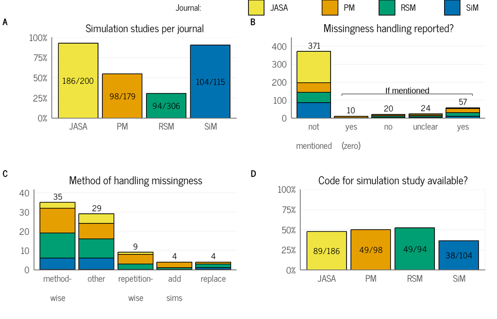

```r
# create a shared legend
leg_plot <- q2_plot +
  theme(legend.text = element_text(size = 17),
        legend.title = element_text(size = 17),
        legend.spacing.x = unit(4, 'in'),
        legend.key.spacing.x = unit(0.25, 'in'))

legend <- cowplot::get_plot_component(leg_plot, 'guide-box-top', return_all = TRUE)



# combine plots
# only use one legend for all plots
p_c <- cowplot::plot_grid(q1_plot_pub,
                          q3_plot_nonmention_pub,
                           q3_1_plot_pub,
                           q4_plot_prop_pub,
                   nrow = 2, labels = c("A", "B", "C", "D"), label_size = 18,
                   align = "h",
                   scale = 0.95)

p_c_leg <- cowplot::plot_grid(legend,
                              p_c,
                              nrow = 2,
                              ncol = 1,
                              rel_widths =
                                c(0.3, 1),
                              rel_heights = c(0.05, 1))

p_c_leg
```

Save plots:

```r
ggsave(here("literature-review/figures/fig_lit_review_results_rev2.pdf"), p_c_leg, width = 15*0.76, height = 10*0.76)
```

# 5 Descriptives

Create one large table with descriptive stats:

```r
data_lr |>
  select(journal, q1_is_sim_study, q2_mentions_missingness, q3_report_dealing_with_missingness, q4_code_available) |>
  mutate(across(-journal, as.factor)) |>
  pivot_longer(cols = -journal, names_to = "question", values_to = "answer") |>
  group_by(journal, question) |>
  count(answer) |>
  pivot_wider(names_from = answer, values_from = n) |>
  select(question, journal, everything()) |>
  arrange(question) |>
  # knitr has issues with \n in table headers
  rename("yes (zero)" = "yes\n(zero)") |>
  mutate(question = case_when(
    question == "q1_is_sim_study" ~ "Q1: Is a simulation study?",
    question == "q2_mentions_missingness" ~ "Q2: Mention missingness?",
    question == "q3_report_dealing_with_missingness" ~ "Q3: Reports dealing with missingness?",
    question == "q4_code_available" ~ "Q4: Code available?"
  )) |>
  knitr::kable()
```

[output not shown]

**R version 4.5.0 (2025-04-11 ucrt)**

**Platform:** x86_64-w64-mingw32/x64

**locale:** *LC_COLLATE=German_Germany.utf8*, *LC_CTYPE=German_Germany.utf8*, *LC_MONETARY=German_Germany.utf8*, *LC_NUMERIC=C* and *LC_TIME=German_Germany.utf8*

**attached base packages:** *stats*, *graphics*, *grDevices*, *utils*, *datasets*, *methods* and *base*

**other attached packages:** *here(v.1.0.1)*, *ggpubr(v.0.6.0)*, *scales(v.1.4.0)*, *cowplot(v.1.1.3)*, *readxl(v.1.4.5)*, *sysfonts(v.0.8.9)*, *lubridate(v.1.9.4)*, *forcats(v.1.0.0)*, *stringr(v.1.5.1)*, *dplyr(v.1.1.4)*, *purrr(v.1.0.4)*, *readr(v.2.1.5)*, *tidyr(v.1.3.1)*, *tibble(v.3.2.1)*, *ggplot2(v.3.5.2.9001)* and *tidyverse(v.2.0.0)*

**loaded via a namespace (and not attached):** *generics(v.0.1.3)*, *rstatix(v.0.7.2)*, *stringi(v.1.8.7)*, *hms(v.1.1.3)*, *digest(v.0.6.37)*, *magrittr(v.2.0.3)*, *evaluate(v.1.0.3)*, *grid(v.4.5.0)*, *timechange(v.0.3.0)*, *RColorBrewer(v.1.1-3)*, *showtextdb(v.3.0)*, *fastmap(v.1.2.0)*, *rprojroot(v.2.0.4)*, *cellranger(v.1.1.0)*, *jsonlite(v.2.0.0)*, *backports(v.1.5.0)*, *Formula(v.1.2-5)*, *pander(v.0.6.6)*, *abind(v.1.4-8)*, *cli(v.3.6.5)*, *rlang(v.1.1.6)*, *withr(v.3.0.2)*, *yaml(v.2.3.10)*, *tools(v.4.5.0)*, *tzdb(v.0.5.0)*, *ggsignif(v.0.6.4)*, *showtext(v.0.9-7)*, *curl(v.6.2.2)*, *broom(v.1.0.8)*, *vctrs(v.0.6.5)*, *R6(v.2.6.1)*, *lifecycle(v.1.0.4)*, *car(v.3.1-3)*, *htmlwidgets(v.1.6.4)*, *pkgconfig(v.2.0.3)*, *pillar(v.1.10.2)*, *gtable(v.0.3.6)*, *Rcpp(v.1.0.14)*, *glue(v.1.8.0)*, *xfun(v.0.52)*, *tidyselect(v.1.2.1)*, *rstudioapi(v.0.17.1)*, *knitr(v.1.50)*, *dichromat(v.2.0-0.1)*, *farver(v.2.1.2)*, *htmltools(v.0.5.8.1)*, *labeling(v.0.4.3)*, *carData(v.3.0-5)*, *rmarkdown(v.2.29)*, *compiler(v.4.5.0)* and *S7(v.0.2.0)*